# Designing and Creating a Database using Baseball Data

Michael Hoang

08/01/2021

# INTRODUCTION

In this project, I will be working with data comprised of games from [Major League Baseball](https://en.wikipedia.org/wiki/Major_League_Baseball) as compiled by the non-profit organization [Retrosheet](https://www.retrosheet.org/). Specifically, it collected info from the 1800s to today. There are 4 major data sets which will be used in creating this database:

- game_log.csv
- park_codes.csv
- person_codes.csv
- team_codes.csv

# STEP 1: Loading Libraries and Loading Data

NOTE: when loading the game_log file, some of the columns aren’t being read correctly as a ‘character’ type. So certain columns need to be represented corrected as such. This can be [referenced here](https://readr.tidyverse.org/reference/read_delim.html).

```r
library(tidyverse)
library(readr)
library(RSQLite)
library(DBI)
library(dbplyr)
setwd("~/MyDatasets")

game.log = read_csv("game_log.csv",
                    col_types = cols(.default = "c",
                                     v_league = "c", h_league = "c",
                                     `3b_umpire_id` = "c", `3b_umpire_name` = "c",
                                     `2b_umpire_id` = "c", `2b_umpire_name` = "c",
                                     `lf_umpire_id` = "c", `lf_umpire_name` = "c",
                                     `rf_umpire_id` = "c", `rf_umpire_name` = "c",
                                     completion = "c", winning_rbi_batter_id = "c",
                                     winning_rbi_batter_id_name = "c", protest = "c",
                                     v_first_catcher_interference = "c",
                                     h_first_catcher_interference = "c"))


park.codes = read.csv("park_codes.csv")

person.codes = read.csv("person_codes.csv")

team.codes = read.csv("team_codes.csv")
```

## Looking at Game Log Data Set

```r
dim(game.log)
```

```
## [1] 171907    161
```

There are over 170,000 + games that were recorded from 1871 to 2016. Each of these entries have the following entries:

- General information pertaining to the game
- Team statistics for both the home and visiting team
- A list of information of all the players, managers, coach and umpires

Here is a link to a [text file](https://dsserver-prod-resources-1.s3.amazonaws.com/376/game_log_fields.txt) that goes into detail of all the information of the entries in this data set.

Within the game log, each player has a defensive position listed, b/t the numbers 1-10. Based on the reference here, the breakdown of the numbering works as the following:

| ** NUMBER ** | ** POSITION ** |
| --- | --- |
| 1 | Pitcher |
| 2 | Catcher |
| 3 | 1st Baseman |
| 4 | 2nd Baseman |
| 5 | 3rd Baseman |
| 6 | Shortstop |
| 7 | Left Fielder |
| 8 | Center Fielder |
| 9 | Right Fielder |
| 10 | Designated Hitter |

Prior to the formalized MLB that we know today, which comprises of the American League (AL) and the National League (NL), there were several other leagues that had existed prior that have since gone defunct. These leagues included:

- AA = American Association
- FL = Federal League
- PL = Players League
- UA = Union Association

```r
dim(person.codes)
```

```
## [1] 20494     7
```

With the person_codes data set, it encompasses data pertaining to all of the personnel (over 20,000 of them) that had been involved in any of those 170,000 + games. The information that this data set contains are:

| ** Variable ** | ** Description ** |
| --- | --- |
| id | identifier of the person |
| last | last name of the person |
| first | first name of the person |
| player_debut | date when the person debut as a player |
| mgr_debut | date when the person debut as a manager |
| coach_debut | date when the person debut as a coach |
| ump_debut | date when the person debut as an umpire |

```r
head(park.codes)
```

```
##   park_id                          name
## 1   ALB01                Riverside Park
## 2   ALT01                 Columbia Park
## 3   ANA01      Angel Stadium of Anaheim
## 4   ARL01             Arlington Stadium
## 5   ARL02 Rangers Ballpark in Arlington
## 6   ATL01 Atlanta-Fulton County Stadium
##                                        aka      city state      start
## 1                                             Albany    NY 09/11/1880
## 2                                            Altoona    PA 04/30/1884
## 3            Edison Field; Anaheim Stadium   Anaheim    CA 04/19/1966
## 4                                          Arlington    TX 04/21/1972
## 5 The Ballpark in Arlington; Ameriquest Fl Arlington    TX 04/11/1994
## 6                                            Atlanta    GA 04/12/1966
##          end league                                          notes
## 1 05/30/1882     NL TRN:9/11/80;6/15&9/10/1881;5/16-5/18&5/30/1882
## 2 05/31/1884     UA
## 3                AL
## 4 10/03/1993     AL
## 5                AL
## 6 09/23/1996     NL
```

This is a data set pertaining to information about the park. Some entries for this data set includes:

| **VARIABLE** | **DESCRIPTION** |
| --- | --- |
| park_id | Identifier for the park |
| name | Name of the park |
| aka | Alternate name for the park |
| city | Name of the city where the park is located |
| state | State where the park is located |
| start | Start date when the park was used to host team |
| end | End date when the park was used to host team |
| league | The league that the team was associated with |
| notes | Additional notes pertaining to the park |

```r
head(team.codes)
```

```
##   team_id league start  end      city        nickname franch_id seq
## 1     ALT     UA  1884 1884   Altoona Mountain Cities       ALT   1
## 2     ARI     NL  1998    0   Arizona    Diamondbacks       ARI   1
## 3     BFN     NL  1879 1885   Buffalo          Bisons       BFN   1
## 4     BFP     PL  1890 1890   Buffalo          Bisons       BFP   1
## 5     BL1         1872 1874 Baltimore        Canaries       BL1   1
## 6     BL2     AA  1882 1891 Baltimore         Orioles       BL2   1
```

This is a data set pertaining to information about the team. Some entries for this data set includes:

[output not shown]

# STEP 2: Importing Data into SQLite

```r
conn = dbConnect(SQLite(), 'mlb.db')

dbWriteTable(conn = conn, name = 'game_log',
             value = game.log, row.names = FALSE, header = TRUE)

dbWriteTable(conn = conn, name = 'park_codes',
             value =  park.codes, row.names =  FALSE, header = TRUE)

dbWriteTable(conn = conn, name = "person_codes",
             value = person.codes, row.names = FALSE, header = TRUE)

dbWriteTable(conn = conn, name = "team_codes",
             value = team.codes, row.names = FALSE, header = TRUE)

dbListTables(conn)
```

```
## [1] "game_log"     "park_codes"   "person_codes" "team_codes"
```

Now that the first step was to create the necessary tables within the database (entitled “mlb.db”), we will also need to do a bit of modification with creating a new column in the game_log table called “**game_id**”. This game_id is made up of three parts: (1) date, (2) h_name (i.e. home team name) and (3) number_of_game as to indicate the number of game that is played that day with 0 = single game, 1 = 1st of a double-header and 2 = 2nd of a double-header.

```r
alter_game_log_command = "ALTER TABLE game_log ADD COLUMN game_id TEXT;"

dbExecute(conn, alter_game_log_command)
```

```
## [1] 0
```

```r
dbGetQuery(conn, "SELECT * FROM game_log LIMIT 2;") # Check to see if the column is actually found in game_log
```

```
##       date number_of_game day_of_week v_name v_league v_game_number h_name
## 1 18710504              0         Thu    CL1     <NA>             1    FW1
## 2 18710505              0         Fri    BS1     <NA>             1    WS3
##   h_league h_game_number v_score h_score length_outs day_night completion
## 1     <NA>             1       0       2          54         D       <NA>
## 2     <NA>             1      20      18          54         D       <NA>
##   forefeit protest park_id attendance length_minutes v_line_score h_line_score
## 1     <NA>    <NA>   FOR01        200            120    000000000    010010000
## 2     <NA>    <NA>   WAS01       5000            145    107000435    640113030
##   v_at_bats v_hits v_doubles v_triples v_homeruns v_rbi v_sacrifice_hits
## 1        30      4         1         0          0     0                0
## 2        41     13         1         2          0    13                0
##   v_sacrifice_flies v_hit_by_pitch v_walks v_intentional_walks v_strikeouts
## 1                 0              0       1                <NA>            6
## 2                 0              0      18                <NA>            5
##   v_stolen_bases v_caught_stealing v_grounded_into_double
## 1              1              <NA>                     -1
## 2              3              <NA>                     -1
##   v_first_catcher_interference v_left_on_base v_pitchers_used
## 1                         <NA>              4               1
## 2                         <NA>             12               1
##   v_individual_earned_runs v_team_earned_runs v_wild_pitches v_balks v_putouts
## 1                        1                  1              0       0        27
## 2                        6                  6              1       0        27
##   v_assists v_errors v_passed_balls v_double_plays v_triple_plays h_at_bats
## 1         9        0              3              0              0        31
## 2        13       10              1              2              0        49
##   h_hits h_doubles h_triples h_homeruns h_rbi h_sacrifice_hits
## 1      4         1         0          0     2                0
## 2     14         2         0          0    11                0
##   h_sacrifice_flies h_hit_by_pitch h_walks h_intentional_walks h_strikeouts
## 1                 0              0       1                <NA>            0
## 2                 0              0      10                <NA>            2
##   h_stolen_bases h_caught_stealing h_grounded_into_double
## 1              0              <NA>                     -1
## 2              1              <NA>                     -1
##   h_first_catcher_interference h_left_on_base h_pitchers_used
## 1                         <NA>              3               1
## 2                         <NA>             14               1
##   h_individual_earned_runs h_team_earned_runs h_wild_pitches h_balks h_putouts
```

[output cut: 53 more lines]

```
##   h_player_4_def_pos h_player_5_id h_player_5_name h_player_5_def_pos
## 1                  6      lennb101     Bill Lennon                  2
## 2                  2      hallg101     George Hall                  7
##   h_player_6_id h_player_6_name h_player_6_def_pos h_player_7_id
## 1      caret101       Tom Carey                  4      mince101
## 2      leona101    Andy Leonard                  4      braia102
##   h_player_7_name h_player_7_def_pos h_player_8_id h_player_8_name
## 1      Ed Mincher                  7      mcdej101 James McDermott
## 2    Asa Brainard                  1      burrh101 Henry Burroughs
##   h_player_8_def_pos h_player_9_id h_player_9_name h_player_9_def_pos
## 1                  8      kellb105      Bill Kelly                  9
## 2                  9      berth101 Henry Berthrong                  8
##   additional_info acquisition_info game_id
## 1            <NA>                Y    <NA>
## 2            HTBF                Y    <NA>
```

```r
updating_game_log_command = "
  UPDATE game_log
  SET game_id = date || h_name || number_of_game
  WHERE game_id IS NULL;
"
dbExecute(conn, updating_game_log_command)
```

```
## [1] 171907
```

```r
dbGetQuery(conn, "SELECT game_id, date, h_name, number_of_game FROM game_log LIMIT 5;") # A check to see if game_id is properly set
```

```
##        game_id     date h_name number_of_game
## 1 18710504FW10 18710504    FW1              0
## 2 18710505WS30 18710505    WS3              0
## 3 18710506RC10 18710506    RC1              0
## 4 18710508CH10 18710508    CH1              0
## 5 18710509TRO0 18710509    TRO              0
```

# STEP 3: Looking for normalization opportunities

In looking for opportunities to be able to reduce the redundancy and improve the integrity of the data, there are several ways that this could be accomplished with this data:

- It is possible to reproduce the debut dates of players from the person_codes using the data from game_log.
- Start, end and sequence columns in team_codes can also be reproduced via game_log
- start & end years within park_codes can be reproduced via game_log
- As there are a number of cases where ID + player name are found in game_log, we can instead remove them and use the name data found within person_codes
- In game_log the offensive + defensive stats are repeated. It is possible that we can break these out and have a table that list each game twice with one for each team and remove the column repetition in game_log
- We can also remove the listing for the 9 player position on each team and have a table that tracks the player appearance + position instead
- We can also just have an individual table for players, umpires and managers instead of having the repeat columns in the game_log
- We can also have a separate table for awards and such instead of having it in game_log

# STEP 4: Planning a Schema

While we can very much create a personal schema that connects these various tables together, one schema has been previously provided as shown:

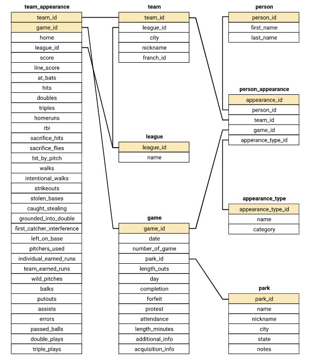

.

# STEP 5: Creating Tables Without Foreign Keys

The first part is to create a new “person” table that consists of (a) person_id set as the primary key, (b) first_name and (c) last_name. Looking at the information needed for this table, it can be gathered from the person_codes table.

```r
create_person_table_command = "
  CREATE TABLE IF NOT EXISTS person(
      person_id TEXT PRIMARY KEY,
      first_name TEXT,
      last_name TEXT
  );
"

dbExecute(conn, create_person_table_command)
```

```
## [1] 0
```

```r
inserting_data_into_person = "
  INSERT INTO person
  SELECT
    id,
    first,
    last
  FROM person_codes;
"

dbExecute(conn, inserting_data_into_person)
```

```
## [1] 20494
```

```r
check_query_2 = "SELECT * FROM person LIMIT 5;"

dbGetQuery(conn, check_query_2)
```

```
##   person_id first_name last_name
## 1  aardd001      David   Aardsma
## 2  aaroh101       Hank     Aaron
## 3  aarot101     Tommie     Aaron
## 4  aased001        Don      Aase
## 5  abada001       Andy      Abad
```

The next step is to create a new “park” table that consists of (a) park_id, (b) name, (c) nickname, (d) city, (e) state and (f) notes. All this information could be gathered from the park_codes table.

```r
create_park_table_command = "
  CREATE TABLE park(
    park_id TEXT PRIMARY KEY,
    name TEXT,
    nickname TEXT,
    city TEXT,
    state TEXT,
    notes TEXT
  );
"

dbExecute(conn, create_park_table_command)
```

```
## [1] 0
```

```r
inserting_data_into_park = "
  INSERT INTO park
  SELECT
    park_id,
    name,
    aka,
    city,
    state,
    notes
  FROM park_codes;
"

dbExecute(conn, inserting_data_into_park)
```

```
## [1] 252
```

```r
dbGetQuery(conn, "SELECT * FROM park LIMIT 5;")
```

```
##   park_id                          name
## 1   ALB01                Riverside Park
## 2   ALT01                 Columbia Park
## 3   ANA01      Angel Stadium of Anaheim
## 4   ARL01             Arlington Stadium
## 5   ARL02 Rangers Ballpark in Arlington
##                                   nickname      city state
## 1                                             Albany    NY
## 2                                            Altoona    PA
## 3            Edison Field; Anaheim Stadium   Anaheim    CA
## 4                                          Arlington    TX
## 5 The Ballpark in Arlington; Ameriquest Fl Arlington    TX
##                                            notes
## 1 TRN:9/11/80;6/15&9/10/1881;5/16-5/18&5/30/1882
## 2
## 3
## 4
## 5
```

The 3rd step is to create the a new “league” table that consists of (a) league_id and (b) name. All this information needs to be manually inputted because (1) there isn’t a league_id column and (2) it’s just 6 entries.

```r
create_league_table_command = "
  CREATE TABLE league(
    league_id TEXT PRIMARY KEY,
    name TEXT
  );
"

dbExecute(conn, create_league_table_command)
```

```
## [1] 0
```

```r
inserting_data_into_league = '
  INSERT INTO league
  VALUES
    ("AL", "American League"),
    ("NL", "National League"),
    ("AA", "American Association"),
    ("FL", "Federal League"),
    ("PL", "Players League"),
    ("UA", "Union Association");
'

dbExecute(conn, inserting_data_into_league)
```

```
## [1] 6
```

```r
dbGetQuery(conn, "SELECT * FROM league;") # A check to see if table was properly made
```

```
##   league_id                 name
## 1        AL      American League
## 2        NL      National League
## 3        AA American Association
## 4        FL       Federal League
## 5        PL       Players League
## 6        UA    Union Association
```

The last step is to create the “appearance_type” table. This table is actually a separate data, found [here](https://dsserver-prod-resources-1.s3.amazonaws.com/376/appearance_type.csv) , that needs to be read and inserted as a table into the data base.

```r
appearance.type = read.csv("appearance_type.csv")

dbWriteTable(conn = conn, name = 'appearance_type',
             value = appearance.type, row.names = FALSE, header = TRUE)

dbGetQuery(conn, "SELECT * FROM appearance_type LIMIT 5;") # A check to see if table was properly made
```

```
##   appearance_type_id     name category
## 1                 O1 Batter 1  offense
## 2                 O2 Batter 2  offense
## 3                 O3 Batter 3  offense
## 4                 O4 Batter 4  offense
## 5                 O5 Batter 5  offense
```

# STEP 6: Adding Team + Game Tables

These tables are unique in that they consist of FOREIGN kEYS that link other tables together, namely PARK to GAME (via park_id) and TEAM to LEAGUE (via league_id). The items to include into the “team” table can be found in the team_codes table. Alternatively, the “game” table can be found in the game_log table.

```r
create_team_table_command <- "
  CREATE TABLE IF NOT EXISTS team (
      team_id TEXT PRIMARY KEY,
      league_id TEXT,
      city TEXT,
      nickname TEXT,
      franch_id TEXT,
      FOREIGN KEY (league_id) REFERENCES league(league_id)
  );
"

dbExecute(conn, create_team_table_command)
```

```
## [1] 0
```

```r
inserting_data_into_team_command = "
  INSERT OR IGNORE INTO team
  SELECT
    team_id,
    league,
    city,
    nickname,
    franch_id
  FROM team_codes;

"

dbExecute(conn, inserting_data_into_team_command)
```

```
## [1] 149
```

```r
dbGetQuery(conn, "SELECT * FROM team LIMIT 5;")
```

```
##   team_id league_id      city        nickname franch_id
## 1     ALT        UA   Altoona Mountain Cities       ALT
## 2     ARI        NL   Arizona    Diamondbacks       ARI
## 3     BFN        NL   Buffalo          Bisons       BFN
## 4     BFP        PL   Buffalo          Bisons       BFP
## 5     BL1           Baltimore        Canaries       BL1
```

```r
# Include the "OR IGNORE" term to avoid issue with inserting duplicate entries in other columnns (namely b/t team_id & franch_id).


create_game_table_command = "
  CREATE TABLE game (
      game_id TEXT PRIMARY KEY,
      date TEXT,
      number_of_game INTEGER,
      park_id TEXT,
      length_outs INTEGER,
      day BOOLEAN,
      completion TEXT,
      forfeit TEXT,
      protest TEXT,
      attendance INTEGER,
      length_minutes INTEGER,
      additional_info TEXT,
      acquisition_into TEXT,
      FOREIGN KEY (park_id) REFERENCES park(park_id)
  )
"

dbExecute(conn, create_game_table_command)
```

```
## [1] 0
```

```r
inserting_data_into_game = '
  INSERT OR IGNORE INTO game
  SELECT
      game_id,
      date,
      number_of_game,
      park_id,
      length_outs,
      CASE
          WHEN day_night = "D" THEN 1
          WHEN day_night = "N" THEN 0
          ELSE NULL
          END
          AS day,
      completion,
      forefeit,
      protest,
      attendance,
      length_minutes,
      additional_info,
      acquisition_info
  FROM game_log;
'

dbExecute(conn, inserting_data_into_game)
```

```
## [1] 171907
```

```r
dbGetQuery(conn, 'SELECT * FROM game LIMIT 5;')
```

```
##        game_id     date number_of_game park_id length_outs day completion
## 1 18710504FW10 18710504              0   FOR01          54   1       <NA>
## 2 18710505WS30 18710505              0   WAS01          54   1       <NA>
## 3 18710506RC10 18710506              0   RCK01          54   1       <NA>
## 4 18710508CH10 18710508              0   CHI01          54   1       <NA>
## 5 18710509TRO0 18710509              0   TRO01          54   1       <NA>
##   forfeit protest attendance length_minutes additional_info acquisition_into
## 1    <NA>    <NA>        200            120            <NA>                Y
## 2    <NA>    <NA>       5000            145            HTBF                Y
## 3    <NA>    <NA>       1000            140            <NA>                Y
## 4    <NA>    <NA>       5000            150            <NA>                Y
## 5    <NA>    <NA>       3250            145            HTBF                Y
```

# STEP 7: Adding the Team Appearance Table

The “team_appearance” table will be made next, which consists of several PRIMARY KEYS (team_id, game_id) along with a FOREIGN KEY (league_id). The majority of the items found here can be gained from the game_log table. It is important to note here that inserting home column means that we’ll have a boolean column that differentiated between home and visiting teams. A way to make inserting this data cleanly is to use the UNION clause that combines the home and visiting variables together

```r
create_team_appearance_command = "
  CREATE TABLE team_appearance (
    team_id TEXT,
    game_id TEXT,
    home BOOLEAN,
    league_id TEXT,
    score INTEGER,
    line_score TEXT,
    at_bats INTEGER,
    hits INTEGER,
    doubles INTEGER,
    triples INTEGER,
    homeruns INTEGER,
    rbi INTEGER,
    sacrifice_hits INTEGER,
    sacrifice_flies INTEGER,
    hit_by_pitch INTEGER,
    walks INTEGER,
    intentional_walks INTEGER,
    strikeouts INTEGER,
    stolen_bases INTEGER,
    caught_stealing INTEGER,
    grounded_into_double INTEGER,
    first_catcher_interference INTEGER,
    left_on_base INTEGER,
    pitchers_used INTEGER,
    individual_earned_runs INTEGER,
    team_earned_runs INTEGER,
    wild_pitches INTEGER,
    balks INTEGER,
    putouts INTEGER,
    assists INTEGER,
    errors INTEGER,
    passed_balls INTEGER,
    double_plays INTEGER,
    triple_plays INTEGER,
    PRIMARY KEY(team_id, game_id),
    FOREIGN KEY (team_id) REFERENCES team(team_id),
    FOREIGN KEY (game_id) REFERENCES game(game_id),
    FOREIGN KEY (league_id) REFERENCES league(league_id)
  );
"

dbExecute(conn, create_team_appearance_command)
```

```
## [1] 0
```

```r
insert_to_team_appearance = "

  INSERT INTO team_appearance
    SELECT
      h_name,
      game_id,
      1 AS home,
      h_league,
      h_score,
          h_line_score,
          h_at_bats,
          h_hits,
          h_doubles,
          h_triples,
          h_homeruns,
          h_rbi,
          h_sacrifice_hits,
          h_sacrifice_flies,
          h_hit_by_pitch,
          h_walks,
          h_intentional_walks,
          h_strikeouts,
          h_stolen_bases,
          h_caught_stealing,
          h_grounded_into_double,
          h_first_catcher_interference,
          h_left_on_base,
          h_pitchers_used,
          h_individual_earned_runs,
          h_team_earned_runs,
          h_wild_pitches,
          h_balks,
          h_putouts,
          h_assists,
          h_errors,
          h_passed_balls,
          h_double_plays,
          h_triple_plays
      FROM game_log
    UNION
      SELECT
          v_name,
          game_id,
          0 AS home,
          v_league,
          v_score,
          v_line_score,
          v_at_bats,
          v_hits,
          v_doubles,
          v_triples,
          v_homeruns,
          v_rbi,
          v_sacrifice_hits,
          v_sacrifice_flies,
          v_hit_by_pitch,
          v_walks,
          v_intentional_walks,
          v_strikeouts,
          v_stolen_bases,
          v_caught_stealing,
          v_grounded_into_double,
          v_first_catcher_interference,
          v_left_on_base,
          v_pitchers_used,
          v_individual_earned_runs,
          v_team_earned_runs,
          v_wild_pitches,
          v_balks,
          v_putouts,
          v_assists,
          v_errors,
          v_passed_balls,
          v_double_plays,
          v_triple_plays
      from game_log;
"

dbExecute(conn, insert_to_team_appearance)
```

```
## [1] 343814
```

```r
dbGetQuery(conn, "SELECT *
                  FROM team_appearance
                  WHERE league_id = (SELECT league_id FROM game)
                  ORDER BY game_id DESC
                  LIMIT 5;
                  ")
```

```
##   team_id      game_id home league_id score line_score at_bats hits doubles
## 1     MIA 20161002WAS0    0        NL     7  000230020      38   14       1
## 2     WAS 20161002WAS0    1        NL    10  03023002x      30   10       2
## 3     TBA 20161002TEX0    0        AL     6 0210001002      42   13       6
## 4     TEX 20161002TEX0    1        AL     4 0101000110      40   11       0
## 5     PIT 20161002SLN0    0        NL     4  000020200      35    9       0
##   triples homeruns rbi sacrifice_hits sacrifice_flies hit_by_pitch walks
## 1       1        2   7              1               0            0     3
## 2       0        1  10              1               1            1     8
## 3       0        0   5              0               1            0     3
## 4       0        1   4              0               0            0     6
## 5       0        1   4              0               0            0     4
##   intentional_walks strikeouts stolen_bases caught_stealing
## 1                 2         10            1               1
## 2                 0          3            2               0
```

[output cut: 21 more lines]

```r
# CHECK ON THE TABLE
```

# STEP 8: Adding the Person Appearance Table

This table is essentially linking the multiple tables together and is composed on 1 PRIMARY KEY (appearance_id) and 4 FOREIGN KEY (person_id, team_id, game_id and appearance_type_id). This is to be used to cross-regerence with other tables, so we’ll need to use a similar technique as with creating the team_appearance but expanded to write one for each column.

```r
create_person_appearance_command <- "CREATE TABLE person_appearance(
  appearance_id INTEGER PRIMARY KEY,
  person_id TEXT,
  team_id TEXT,
  game_id TEXT,
  appearance_type_id,
  FOREIGN KEY (person_id) REFERENCES person(person_id),
  FOREIGN KEY (team_id) REFERENCES team(team_id),
  FOREIGN KEY (game_id) REFERENCES game(game_id),
  FOREIGN KEY (appearance_type_id) REFERENCES appearance_type(appearance_type_id)
);"

dbExecute(conn, create_person_appearance_command)
```

```
## [1] 0
```

```r
inserting_data_into_person_appearance = "

  INSERT OR IGNORE INTO person_appearance (
      game_id,
      team_id,
      person_id,
      appearance_type_id
  )
      SELECT
          game_id,
          NULL,
          hp_umpire_id,
          'UHP'
      FROM game_log
      WHERE hp_umpire_id IS NOT NULL

  UNION

      SELECT
          game_id,
          NULL,
          [1b_umpire_id],
          'U1B'
      FROM game_log
      WHERE '1b_umpire_id' IS NOT NULL

  UNION

      SELECT
          game_id,
          NULL,
          [2b_umpire_id],
          'U2B'
      FROM game_log
      WHERE [2b_umpire_id] IS NOT NULL

  UNION

      SELECT
          game_id,
          NULL,
          [3b_umpire_id],
          'U3B'
      FROM game_log
      WHERE [3b_umpire_id] IS NOT NULL

  UNION

      SELECT
          game_id,
          NULL,
          lf_umpire_id,
          'ULF'
      FROM game_log
      WHERE lf_umpire_id IS NOT NULL

  UNION

      SELECT
          game_id,
          NULL,
          rf_umpire_id,
          'URF'
      FROM game_log
      WHERE rf_umpire_id IS NOT NULL

  UNION

      SELECT
          game_id,
          v_name,
          v_manager_id,
          'MM'
      FROM game_log
      WHERE v_manager_id IS NOT NULL

  UNION

      SELECT
          game_id,
          h_name,
          h_manager_id,
          'MM'
      FROM game_log
      WHERE h_manager_id IS NOT NULL

  UNION

      SELECT
          game_id,
          CASE
              WHEN h_score > v_score THEN h_name
              ELSE v_name
              END,
          winning_pitcher_id,
          'AWP'
      FROM game_log
      WHERE winning_pitcher_id IS NOT NULL

  UNION

      SELECT
          game_id,
          CASE
              WHEN h_score < v_score THEN h_name
              ELSE v_name
              END,
          losing_pitcher_id,
          'ALP'
      FROM game_log
      WHERE losing_pitcher_id IS NOT NULL

  UNION

      SELECT
          game_id,
          CASE
              WHEN h_score > v_score THEN h_name
              ELSE v_name
              END,
          saving_pitcher_id,
          'ASP'
      FROM game_log
      WHERE saving_pitcher_id IS NOT NULL

  UNION

      SELECT
          game_id,
          CASE
              WHEN h_score > v_score THEN h_name
              ELSE v_name
              END,
          winning_rbi_batter_id,
          'AWB'
      FROM game_log
      WHERE winning_rbi_batter_id IS NOT NULL

  UNION

      SELECT
          game_id,
          v_name,
          v_starting_pitcher_id,
          'PSP'
      FROM game_log
      WHERE v_starting_pitcher_id IS NOT NULL

  UNION

      SELECT
          game_id,
          h_name,
          h_starting_pitcher_id,
          'PSP'
      FROM game_log
      WHERE h_starting_pitcher_id IS NOT NULL;


"

dbExecute(conn, inserting_data_into_person_appearance)
```

```
## [1] 1670985
```

This initial step was used to input all the data for non-player individuals (such as umpires, managers, etc.) along with players that had prominent awards or achievements such as winning pitchers or hitters for a particular game. Obviously, there are more players that will need to be added. This can be done in a similar manner with the above option, but with 36 different permutations (2 for home VS away, 2 for offense VS defense and 9 for each of the 9 positions), there is an easier way.

In the first half of the template, which denotes the OFFENSIVE SIDE OF THINGS, it is essentially inserting

```
  (1) game_id with game_id found in game_log,
  (2) team_id with the team_id differentiated by either Home team or Visiting team differentiator
  (3) person_id with person_id differentiated by the home vs visiting team identifier AND the corresponding number indicator for field positioning
  (4) the apearance_type_id differentiated by the numerical indicator for batting line-up
```

Similarly, the second half of the template will denote the DEFENSIVE SIDE OF THINGS.

Finally, using the function “gsub”, we will be replacing the %s and %f values with the corresponding letters and numbers

```r
for (letter in c("h", "v")) {
  for (num in 1:9) {
    template <- '
      INSERT INTO person_appearance (
          game_id,
          team_id,
          person_id,
          appearance_type_id
      )
          SELECT
              game_id,
              %s_name,
              %s_player_%f_id,
              "O%f"
          FROM game_log
          WHERE %s_player_%f_id IS NOT NULL

      UNION

          SELECT
              game_id,
              %s_name,
              %s_player_%f_id,
              "D" || CAST(%s_player_%f_def_pos AS INT)
          FROM game_log
          WHERE %s_player_%f_id IS NOT NULL;
    '
    # replace all of the %s and %f with the correct letter number
    template <- gsub("%s", letter, template, fixed = TRUE)
    template <- gsub("%f", num, template, fixed = TRUE)

    dbExecute(conn, template)
  }
}


dbGetQuery(conn, "SELECT * FROM person_appearance LIMIT 5;")
```

```
##   appearance_id person_id team_id      game_id appearance_type_id
## 1             1      <NA>    <NA> 18710504FW10                U1B
## 2             2  boakj901    <NA> 18710504FW10                UHP
## 3             3  paboc101     CL1 18710504FW10                 MM
## 4             4  prata101     CL1 18710504FW10                ALP
## 5             5  prata101     CL1 18710504FW10                PSP
```

# STEP 9: Removing the Original Tables

```r
dbListTables(conn) # Don't need game_log, park_codes, team_codes, person_codes
```

```
##  [1] "appearance_type"   "game"              "game_log"
##  [4] "league"            "park"              "park_codes"
##  [7] "person"            "person_appearance" "person_codes"
## [10] "team"              "team_appearance"   "team_codes"
```

```r
# I only want: team_appearance, team, person, person_appearance, league, appearance_type, game and park

tables <- c("game_log", 'park_codes', 'team_codes', 'person_codes')

for (t in tables) {
    dbRemoveTable(conn, t)
}

dbListTables(conn)
```

```
## [1] "appearance_type"   "game"              "league"
## [4] "park"              "person"            "person_appearance"
## [7] "team"              "team_appearance"
```

```r
dbDisconnect(conn)
```